# Relatório Sintético Geral - Autoavaliação UFRPE 2020

Este relatório apresenta os resultados quantitativos da autoavaliação 2020 da Universidade Federal Rural de Pernambuco (UFRPE), conduzida pela Comissão Própria de Avaliação (CPA). Neste ano foram avaliadas as Políticas Acadêmicas da instituição, contemplando cinco temáticas: políticas de ensino, de pesquisa, de extensão, de apoio estudantil, e também a comunicação institucional.

A Seção 1 apresenta uma visão geral dos resultados da autoavaliação com base na média ponderada das respostas obtidas. A Seção 2 contém os resultados completos dos questionários de autoavaliação aplicados no Campus Dois Irmãos, na Unidade Acadêmica do Cabo de Santo Agostinho (UACSA) e na Unidade Acadêmica de Serra Talhada (UAST). Os resultados completos da Unidade Acadêmica de Educação à Distância e Tecnologia (UAEADTec) são apresentados na Seção 3. Em ambos os casos, os resultados são classificados por temática e por segmento (estudantes, docentes e técnicos). Considerações sobre a metodologia de avaliação são apresentadas na Seção 4. Por último, a Seção 5 conclui este relatório.

# 1 Visão Geral

A Autoavaliação 2020 da UFRPE contou com a participação de 2000 estudantes, 484 docentes e 257 técnicos, englobando o Campus Dois Irmãos, a Unidade Acadêmica do Cabo de Santo Agostinho (UACSA), a Unidade Acadêmica de Serra Talhada (UAST) e a Unidade Acadêmica de Educação à Distância e Tecnologia (UAEADTec)

A seguir são apresentadas as médias ponderadas dos resultados da avaliação feita por cada segmento acadêmico.

## 1.1 Estudantes (Campus Dois Irmãos, UACSA, UAST)

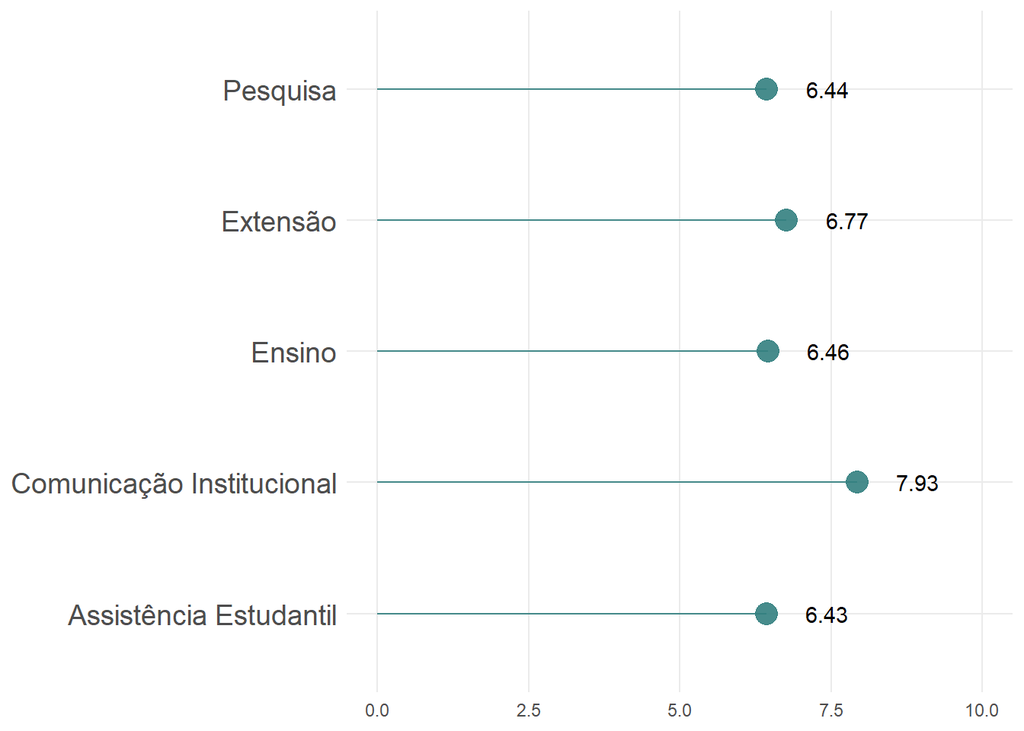

Os dados apresentados acima apontam a média ponderada das respostas de cada tema, dadas pelos estudantes dos Campus Dois Irmãos, UACSA e UAST. Durante o período de aplicação do questionário, essas unidades e a sede contavam com 9528 estudantes aptos a participar da avaliação, dos quais 1742 (18.28%) responderam ao questionário. A participação média foi de 42,5 estudantes por curso, com desvio padrão amostral de 28,4.

Considerando a totalidade das respostas desses estudantes, referentes às Políticas Acadêmicas da UFRPE, 2.75% das respostas foram "péssimo", 5.91% foram "ruim", 19.11% foram "regular", 29.79% foram "bom", 19.76% foram "excelente", e 22.68% foram outras opções de resposta.

## 1.2 Estudantes (UAEADTec)

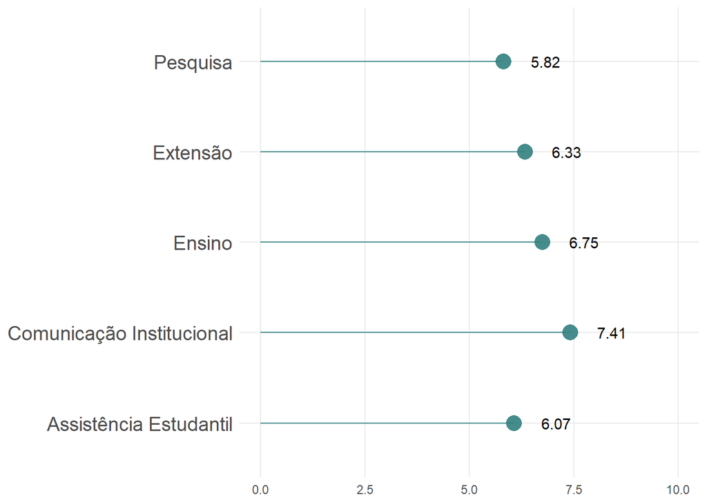

Os dados apresentados acima apontam a média ponderada das respostas de cada tema, dadas pelos estudantes da Unidade Acadêmica de Educação à Distância e Tecnologia (UAEADTec). Durante o período de aplicação do questionário, a UAEADTec contava com 629 estudantes aptos a participar da avaliação, dos quais 258 (41.02%) responderam ao questionário. A participação média foi de 32,3 estudantes por curso, com desvio padrão amostral de 18,9.

Considerando a totalidade das respostas desses estudantes, referentes às Políticas Acadêmicas da UFRPE, 3.94% das respostas foram "péssimo", 4.71% foram "ruim", 16.87% foram "regular", 33.79% foram "bom", 16.49% foram "excelente", e 24.21% foram outras opções de resposta.

## 1.3 Docentes (Campus Dois Irmãos, UACSA, UAST)

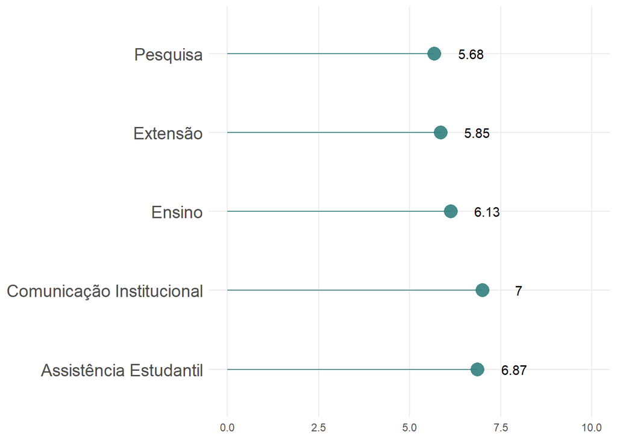

Os dados apresentados acima apontam a média ponderada das respostas de cada tema, dadas pelos servidores docentes dos Campus Dois Irmãos, UACSA e UAST. Durante o período de aplicação do questionário, essas unidades e a sede contavam com 1019 docentes aptos a participar da avaliação, dos quais 449 (44.06%) responderam ao questionário.

Considerando a totalidade das respostas desses docentes, referentes às Políticas Acadêmicas da UFRPE, 3.45% das respostas foram "péssimo", 8.29% foram "ruim", 25.33% foram "regular", 33.35% foram "bom", 10.04% foram "excelente", e 19.54% foram outras opções de resposta.

## 1.4 Docentes (UAEADTec)

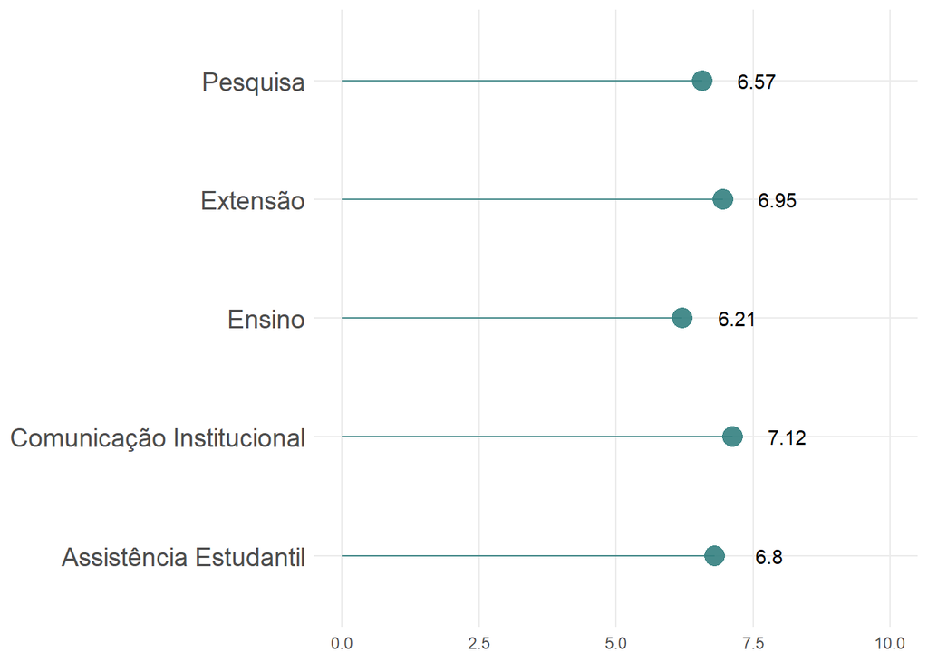

Os dados apresentados acima apontam a média ponderada das respostas de cada tema, dadas pelos servidores docentes da Unidade Acadêmica de Educação à Distância e Tecnologia (UAEADTec). Durante o período de aplicação do questionário, a UAEADTec contava com 38 docentes aptos a participar da avaliação, dos quais 35 (92.11%) responderam ao questionário.

Considerando a totalidade das respostas desses docentes, referentes às Políticas Acadêmicas da UFRPE, 3.25% das respostas foram "péssimo", 7.17% foram "ruim", 17.54% foram "regular", 38.66% foram "bom", 15.41% foram "excelente", e 17.98% foram outras opções de resposta.

## 1.5 Técnicos (Campus Dois Irmãos, UACSA, UAST)

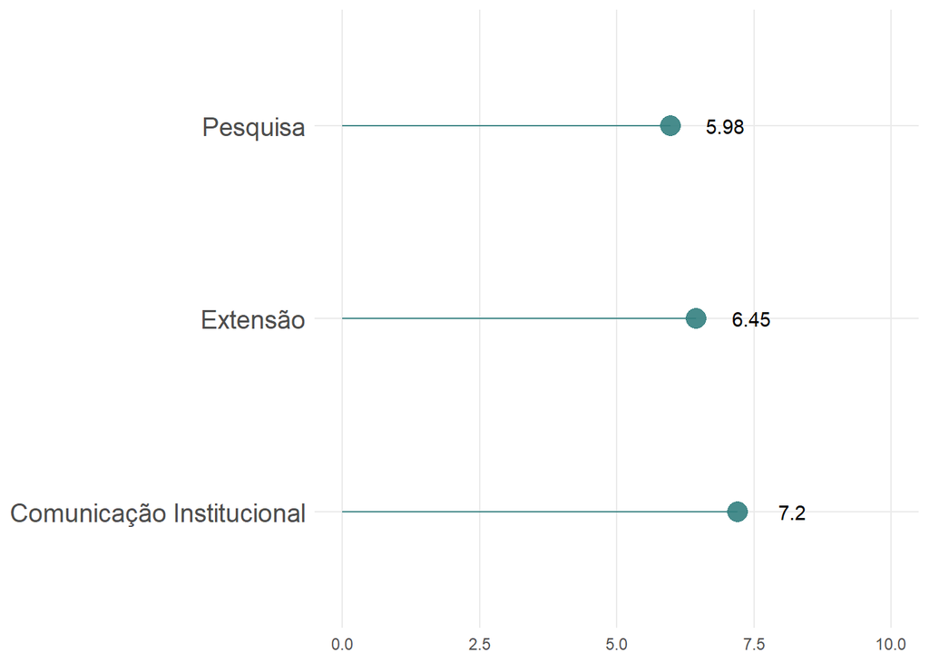

Os dados apresentados acima apontam a média ponderada das respostas de cada tema, dadas pelos servidores técnicos dos Campus Dois Irmãos, UACSA e UAST. Durante o período de aplicação do questionário, essas unidades e a sede contavam com 906 técnicos aptos a participar da avaliação, dos quais 244 (26.93%) responderam ao questionário.

Considerando a totalidade das respostas desses técnicos, referentes às Políticas Acadêmicas da UFRPE, 2.64% das respostas foram "péssimo", 4.92% foram "ruim", 15.62% foram "regular", 29% foram "bom", 14.16% foram "excelente", e 33.66% foram outras opções de resposta.

*Observação: o questionário aplicado aos técnicos não contemplou as temáticas Ensino e Assistência Estudantil.*

## 1.6 Técnicos (UAEADTec)

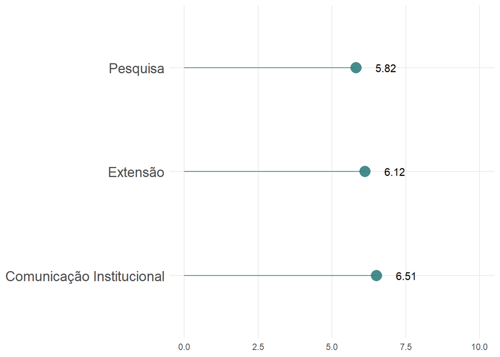

Os dados apresentados acima apontam a média ponderada das respostas de cada tema, dadas pelos servidores técnicos da Unidade Acadêmica de Educação à Distância e Tecnologia (UAEADTec). Durante o período de aplicação do questionário, a UAEADTec contava com 13 técnicos aptos a participar da avaliação, dos quais 13 (100%) responderam ao questionário.

Considerando a totalidade das respostas desses técnicos, referentes às Políticas Acadêmicas da UFRPE, 2.4% das respostas foram "péssimo", 11.06% foram "ruim", 18.75% foram "regular", 28.85% foram "bom", 12.02% foram "excelente", e 26.92% foram outras opções de resposta.

*Observação: o questionário aplicado aos técnicos não contemplou as temáticas Ensino e Assistência Estudantil.*

# 2 Resultados da Avaliação das Políticas Acadêmicas (Campus Dois Irmãos, UACSA e UAST)

Esta seção apresenta os resultados referentes à avaliação das políticas acadêmicas da UFRPE, conforme respondido pelos integrantes do Campus Dois Irmãos, da Unidade Acadêmica do Cabo de Santo Agostinho (UACSA) e da Unidade Acadêmica de Serra Talhada (UAST). Os resultados referentes à Unidade Acadêmica de Educação à Distância e Tecnologia (UAEADTec) são apresentados na Seção 3.

A seguir são apresentados os resultados classificados por temática: ensino, pesquisa, extensão, apoio estudantil e comunicação institucional. Em cada temática, os resultados são separados por segmentos: estudantes, docentes e técnicos. Essa separação é feita visto que as perguntas são diferentes para cada segmento.

## 2.1 Avaliação do ensino (Campus Dois Irmãos, UACSA e UAST)

### 2.1.1 Estudantes

Média

Item avaliado

Péssimo (0)

Ruim (2.5)

Regular (5)

Bom (7.5)

Excelente (10)

OOR*

7.8

1. Avalie o Sistema de Seleção Unificada (Sisu) como a principal forma de ingresso nos cursos de graduação da UFRPE

19

54

265

714

645

45

7.1

2. Avalie as práticas de interdisciplinaridade no seu curso

20

77

418

736

386

105

7.1

3. Avalie a diversificação de estratégias de ensino

23

90

442

730

430

27

7.2

4. Avalie a diversificação de instrumentos avaliativos

24

87

416

766

432

17

6.4

5. Avalie o Ambiente Virtual de Aprendizagem (AVA) nas atividades de ensino

52

134

495

624

255

182

6.7

6. Avalie a articulação entre teoria e prática nas disciplinas

28

137

521

712

332

12

7.0

7. Avalie as práticas de integração entre atividades de ensino e Pesquisa

26

96

373

645

327

275

6.8

8. Avalie as práticas de integração entre atividades de ensino e extensão

26

106

360

576

269

405

6.9

9. Avalie a atuação da Comissão de Orientação e Acompanhamento Acadêmico (COAA)

39

54

206

396

217

830

6.3

10. Avalie a oferta de bolsas para o programa de monitoria da UFRPE

55

164

468

545

233

277

6.5

11. Avalie as ações institucionais de prevenção à retenção em disciplinas do seu curso

52

114

340

561

230

445

6.1

12. Avalie as ações institucionais de prevenção à evasão no seu curso

79

183

396

461

232

391

7.0

13. Avalie o acesso ao Projeto Pedagógico do seu Curso (PPC)

34

75

402

685

346

200

4.1

14. Avalie a oferta de vagas em programas de intercâmbio nacional para graduandos

216

273

329

183

67

674

3.9

15. Avalie a oferta de vagas em programas de intercâmbio internacional para graduandos

263

281

321

164

85

628

*OOR: Outras opções de resposta. Para saber qual o texto da(s) respostas(s) de uma questão em específico, posicione o cursor do mouse sobre o valor correspondente na última coluna.

### 2.1.2 Docentes

Média

Item avaliado

Péssimo (0)

Ruim (2.5)

Regular (5)

Bom (7.5)

Excelente (10)

OOR*

6.8

1. Avalie o Sistema de Seleção Unificada (Sisu) como a principal forma de ingresso nos cursos de graduação da UFRPE.

6

33

111

179

86

34

6.2

2. Avalie as práticas de interdisciplinaridade nos cursos em que você atua

2

42

152

183

32

38

6.4

3. Avalie o Ambiente Virtual de Aprendizagem (AVA) nas atividades de ensino

8

30

100

155

37

119

7.2

4. Avalie a articulação entre teoria e prática nas disciplinas

3

9

97

270

66

4

6.9

5. Avalie as práticas de integração entre atividades de ensino e Pesquisa

4

20

109

232

63

21

6.2

6. Avalie as práticas de integração entre atividades de ensino e extensão

6

50

149

163

51

30

5.5

7. Avalie as ações institucionais de capacitação para práticas pedagógicas voltadas aos estudantes com deficiência

15

48

128

102

19

137

7.0

8. Avalie a atuação da Comissão de Orientação e Acompanhamento Acadêmico (COAA)

4

23

77

177

60

108

6.3

9. Avalie a oferta institucional de formação didático-pedagógica contínua na UFRPE

8

31

137

169

34

70

6.2

10. Avalie a oferta de bolsas para o programa de monitoria da UFRPE

7

42

148

186

34

32

6.4

11. Avalie as ações institucionais de prevenção à retenção

9

24

124

185

37

70

6.3

12. Avalie as ações institucionais de prevenção à evasão

8

22

145

176

26

72

5.6

13. Avalie como a UFRPE acompanha o estudante egresso

13

45

115

94

25

157

4.5

14. Avalie a oferta de vagas em programas de intercâmbio nacional para docentes

32

66

105

57

10

179

4.4

15. Avalie a oferta de vagas em programas de intercâmbio internacional para docentes

43

64

114

57

11

160

*OOR: Outras opções de resposta. Para saber qual o texto da(s) respostas(s) de uma questão em específico, posicione o cursor do mouse sobre o valor correspondente na última coluna.

### 2.1.3 Técnicos

O questionário dos técnicos não contemplou perguntas sobre ensino.

## 2.2 Avaliação da Pesquisa (Campus Dois Irmãos, UACSA e UAST)

### 2.2.1 Estudantes

Média

Item avaliado

Péssimo (0)

Ruim (2.5)

Regular (5)

Bom (7.5)

Excelente (10)

OOR*

7.0

16. Avalie sua participação em grupos e/ou núcleos de Pesquisa da UFRPE

14

83

250

385

261

749

5.8

17. Avalie sua participação em grupos de Pesquisa com outras Instituições de Ensino Superior (IES)

28

109

192

175

92

1146

6.5

18. Avalie o apoio financeiro da UFRPE para apresentação de trabalhos em eventos

27

92

339

411

174

699

6.0

19. Avalie a oferta de bolsas de iniciação científica

69

165

418

431

197

462

6.9

20. Avalie a promoção de eventos científicos pela UFRPE

30

88

432

618

344

230

*OOR: Outras opções de resposta. Para saber qual o texto da(s) respostas(s) de uma questão em específico, posicione o cursor do mouse sobre o valor correspondente na última coluna.

### 2.2.2 Docentes

Média

Item avaliado

Péssimo (0)

Ruim (2.5)

Regular (5)

Bom (7.5)

Excelente (10)

OOR*

7.1

16. Avalie sua participação em grupos e/ou núcleos de Pesquisa da UFRPE

5

15

101

212

85

31

6.7

17. Avalie sua participação em grupos de Pesquisa com outras Instituições de Ensino Superior (IES)

4

26

111

166

57

85

5.6

18. Avalie a oferta da UFRPE para editais de projetos de Pesquisa

23

49

164

154

21

38

6.1

19. Avalie o apoio da Pró-Reitoria de Pesquisa e Pós-Graduação (PRPPG) para participação em editais de agências de fomento (Pesquisa)

14

42

122

150

38

83

6.4

20. Avalie as parcerias da UFRPE com as instituições externas de Pesquisa

10

19

105

158

34

123

5.1

21. Avalie as parcerias da UFRPE com empresas para o desenvolvimento de Pesquisas

21

51

106

77

16

178

2.9

22. Avalie o apoio financeiro da UFRPE para apresentação de trabalhos em eventos

133

108

97

45

4

62

3.5

23. Avalie o apoio financeiro da UFRPE para publicação de Pesquisas

80

96

101

43

8

121

5.9

24. Avalie a oferta de bolsas de iniciação científica para o desenvolvimento de Pesquisas

12

56

165

154

36

26

6.2

25. Avalie a oferta de editais de incentivo à iniciação científica

13

41

145

177

41

32

6.6

26. Avalie a inserção científica da UFRPE no âmbito nacional

4

24

115

207

34

65

5.1

27. Avalie a inserção científica da UFRPE no âmbito internacional

20

50

152

91

9

127

5.9

28. Avalie a promoção de eventos científicos pela UFRPE

11

57

158

168

33

22

6.3

29. Avalie as ações de cooperação nacional da UFRPE

4

17

102

125

21

180

5.8

30. Avalie as ações de cooperação internacional da UFRPE

15

30

102

104

24

174

*OOR: Outras opções de resposta. Para saber qual o texto da(s) respostas(s) de uma questão em específico, posicione o cursor do mouse sobre o valor correspondente na última coluna.

### 2.2.3 Técnicos

Média

Item avaliado

Péssimo (0)

Ruim (2.5)

Regular (5)

Bom (7.5)

Excelente (10)

OOR*

6.8

1. Avalie sua participação em grupos e/ou núcleos de Pesquisa da UFRPE

0

5

30

44

14

151

6.3

2. Avalie sua participação em grupos de Pesquisa com outras Instituições de Ensino Superior (IES)

0

11

18

34

7

174

5.6

3. Avalie o incentivo da UFRPE para participação de técnicos em projetos de Pesquisa

19

16

45

43

23

98

5.5

4. Avalie o apoio financeiro da UFRPE para apresentação de trabalhos em eventos

13

17

31

37

13

133

5.7

5. Avalie o apoio da UFRPE para publicação de Pesquisas realizadas por técnicos

14

15

25

37

18

135

*OOR: Outras opções de resposta. Para saber qual o texto da(s) respostas(s) de uma questão em específico, posicione o cursor do mouse sobre o valor correspondente na última coluna.

## 2.3 Avaliação da Extensão (Campus Dois Irmãos, UACSA e UAST)

### 2.3.1 Estudantes

Média

Item avaliado

Péssimo (0)

Ruim (2.5)

Regular (5)

Bom (7.5)

Excelente (10)

OOR*

6.9

21. Avalie a sua participação na extensão universitária

14

93

348

457

283

547

6.9

22. Avalie a promoção de eventos culturais e artísticos pela UFRPE

40

112

371

599

343

277

6.5

23. Avalie ações da UFRPE voltadas ao empreendedorismo econômico e social

44

119

357

485

215

522

*OOR: Outras opções de resposta. Para saber qual o texto da(s) respostas(s) de uma questão em específico, posicione o cursor do mouse sobre o valor correspondente na última coluna.

### 2.3.2 Docentes

Média

Item avaliado

Péssimo (0)

Ruim (2.5)

Regular (5)

Bom (7.5)

Excelente (10)

OOR*

6.3

31. Avalie a sua participação na extensão universitária

11

37

139

164

55

43

6.2

32. Avalie a oferta de editais de projetos de extensão da UFRPE

12

33

159

175

39

31

5.4

33. Avalie o apoio da Pró-Reitoria de Extensão e Cultura (PROEXC) para participação em editais de agências de fomento

18

58

111

95

23

144

5.8

34. Avalie as parcerias da UFRPE com instituições externas para extensão

10

35

99

95

21

189

5.3

35. Avalie as parcerias da UFRPE com empresas para o desenvolvimento de ações de extensão

15

40

88

72

11

223

5.7

36. Avalie a promoção de eventos culturais e artísticos pela UFRPE

19

54

137

134

30

75

5.5

37. Avalie as ações da UFRPE voltadas ao empreendedorismo econômico e social

12

44

115

88

17

173

6.6

38. Avalie a inserção da extensão da UFRPE no âmbito regional

8

28

90

158

51

114

*OOR: Outras opções de resposta. Para saber qual o texto da(s) respostas(s) de uma questão em específico, posicione o cursor do mouse sobre o valor correspondente na última coluna.

### 2.3.3 Técnicos

Média

Item avaliado

Péssimo (0)

Ruim (2.5)

Regular (5)

Bom (7.5)

Excelente (10)

OOR*

6.6

6. Avalie a sua participação na extensão universitária

1

9

32

62

13

127

6.8

7. Avalie a oferta da UFRPE para editais de projetos de extensão

6

7

32

71

25

103

5.9

8. Avalie o incentivo da UFRPE para participação de técnicos em projetos de extensão

13

18

34

48

22

109

6.5

9. Avalie a promoção de eventos culturais e artísticos da UFRPE

8

19

56

84

39

38

*OOR: Outras opções de resposta. Para saber qual o texto da(s) respostas(s) de uma questão em específico, posicione o cursor do mouse sobre o valor correspondente na última coluna.

## 2.4 Avaliação da Comunicação Institucional (Campus Dois Irmãos, UACSA e UAST)

### 2.4.1 Estudantes

Média

Item avaliado

Péssimo (0)

Ruim (2.5)

Regular (5)

Bom (7.5)

Excelente (10)

OOR*

8.8

31. Avalie a imagem institucional da UFRPE

2

14

98

558

1052

18

8.1

32. Avalie o site institucional da UFRPE (www.ufrpe.br)

12

23

226

761

704

16

7.5

33. Avalie a acessibilidade do site da UFRPE para pessoas com deficiência

15

31

167

343

258

928

8.3

34. Avalie a interação da UFRPE nas mídias sociais (Facebook. Instagram. YouTube e Twitter)

14

32

222

577

863

34

8.1

35. Avalie a Comunicação da UFRPE com os estudantes

10

37

253

660

782

0

7.3

36. Avalie o atendimento prestado pela Ouvidoria

16

27

153

286

191

1069

7.4

37. Avalie o acesso às resoluções (normas acadêmicas) da UFRPE

18

57

371

826

470

0

*OOR: Outras opções de resposta. Para saber qual o texto da(s) respostas(s) de uma questão em específico, posicione o cursor do mouse sobre o valor correspondente na última coluna.

### 2.4.2 Docentes

Média

Item avaliado

Péssimo (0)

Ruim (2.5)

Regular (5)

Bom (7.5)

Excelente (10)

OOR*

7.8

42. Avalie a imagem institucional da UFRPE

3

5

63

235

138

5

7.3

43. Avalie o site institucional da UFRPE (www.ufrpe.br)

7

21

74

244

102

1

6.4

44. Avalie a acessibilidade do site da UFRPE para pessoas com deficiência

6

24

71

100

32

216

7.7

45. Avalie a interação da UFRPE nas mídias sociais (Facebook. Instagram. YouTube e Twitter)

6

6

72

188

143

34

6.7

46. Avalie a Comunicação interna da UFRPE com a comunidade universitária

16

36

109

199

89

0

7.0

47. Avalie o atendimento prestado pela Ouvidoria

6

7

50

92

43

251

6.1

48. Avalie o acesso às resoluções da UFRPE

31

49

127

184

58

0

*OOR: Outras opções de resposta. Para saber qual o texto da(s) respostas(s) de uma questão em específico, posicione o cursor do mouse sobre o valor correspondente na última coluna.

### 2.4.3 Técnicos

Média

Item avaliado

Péssimo (0)

Ruim (2.5)

Regular (5)

Bom (7.5)

Excelente (10)

OOR*

8.2

10. Avalie a imagem institucional da UFRPE

1

4

21

114

101

3

7.5

11. Avalie o site institucional da UFRPE (www.ufrpe.br)

1

8

48

123

63

1

6.6

12. Avalie a acessibilidade do site da UFRPE para pessoas com deficiência

3

10

38

77

16

100

8.1

13. Avalie a interação da UFRPE nas mídias sociais (Facebook. Instagram. YouTube e Twitter)

1

1

39

96

97

10

6.6

14. Avalie a Comunicação interna da UFRPE com a comunidade universitária

7

17

79

96

45

0

7.3

15. Avalie o atendimento prestado pela Ouvidoria

2

6

18

60

26

132

6.1

16. Avalie o acesso às resoluções da UFRPE

14

29

64

106

31

0

*OOR: Outras opções de resposta. Para saber qual o texto da(s) respostas(s) de uma questão em específico, posicione o cursor do mouse sobre o valor correspondente na última coluna.

## 2.5 Avaliação da Assistência Estudantil (Campus Dois Irmãos, UACSA e UAST)

### 2.5.1 Estudantes

Média

Item avaliado

Péssimo (0)

Ruim (2.5)

Regular (5)

Bom (7.5)

Excelente (10)

OOR*

6.7

24. Avalie a disponibilidade de auxílios de assistência estudantil

59

129

498

682

374

0

5.9

25. Avalie o valor dos auxílios de assistência estudantil

61

178

506

461

157

379

7.9

26. Avalie as ações de acolhimento aos calouros do curso

34

56

239

618

734

61

6.1

27. Avalie as ações de apoio para discentes com dificuldades de aprendizagem

91

149

369

448

231

454

6.1

28. Avalie as ações de apoio para discentes com dificuldades emocionais e/ou psicológicas

109

145

348

425

263

452

6.5

29. Avalie o acompanhamento pedagógico do estágio não obrigatório remunerado pela UFRPE

33

44

190

252

126

1097

5.8

30. Avalie a adequação da metodologia de ensino para discentes com deficiência

77

100

221

242

136

966

*OOR: Outras opções de resposta. Para saber qual o texto da(s) respostas(s) de uma questão em específico, posicione o cursor do mouse sobre o valor correspondente na última coluna.

### 2.5.2 Docentes

Média

Item avaliado

Péssimo (0)

Ruim (2.5)

Regular (5)

Bom (7.5)

Excelente (10)

OOR*

8.2

39. Avalie as ações de acolhimento aos calouros do curso

2

6

37

219

170

15

6.0

40. Avalie as ações da UFRPE de apoio para discentes com dificuldades de aprendizagem

13

35

147

150

32

72

6.4

41. Avalie as ações da UFRPE de apoio para discentes com dificuldades emocionais e/ou psicológicas

12

39

114

179

58

47

*OOR: Outras opções de resposta. Para saber qual o texto da(s) respostas(s) de uma questão em específico, posicione o cursor do mouse sobre o valor correspondente na última coluna.

### 2.5.3 Técnicos

O questionário dos técnicos não contemplou perguntas sobre assistência estudantil.

# 3 Resultados da Avaliação das Políticas Acadêmicas (UAEADTec)

Esta seção apresenta os resultados referentes à avaliação das políticas acadêmicas da UFRPE, conforme respondido pelos integrantes da Unidade Acadêmica de Educação à Distância e Tecnologia (UAEADTec).

A seguir são apresentados os resultados classificados por temática: ensino, pesquisa, extensão, apoio estudantil e comunicação institucional. Em cada temática, os resultados são separados por segmentos: estudantes, docentes e técnicos. Essa separação é feita visto que as perguntas são diferentes para cada segmento.

## 3.1 Avaliação do Ensino (UAEADTec)

### 3.1.1 Estudantes

Média

Item avaliado

Péssimo (0)

Ruim (2.5)

Regular (5)

Bom (7.5)

Excelente (10)

OOR*

8.2

1. Avalie o sistema de ingresso nos cursos de graduação da Unidade Acadêmica de Educação a Distância e Tecnologia - UAEADTec

3

3

21

123

108

0

7.4

2. Avalie as práticas de interdisciplinaridade no seu curso

3

10

49

113

73

10

7.5

3. Avalie a diversificação de estratégias de ensino

4

7

48

125

69

5

7.2

4. Avalie a diversificação de instrumentos avaliativos

7

8

52

126

63

2

7.8

5. Avalie o Ambiente Virtual de Aprendizagem (AVA) nas atividades de ensino

5

4

38

120

91

0

6.9

6. Avalie a articulação entre teoria e prática nas disciplinas

5

13

73

116

50

1

6.8

7. Avalie as práticas de integração entre atividades de ensino e Pesquisa

7

15

65

107

46

18

6.8

8. Avalie as práticas de integração entre atividades de ensino e extensão

5

14

58

119

33

29

7.4

9. Avalie o acesso ao Projeto Pedagógico do seu Curso (PPC)

7

7

39

122

66

17

7.1

10. Avalie a atuação da Comissão de Orientação e Acompanhamento Acadêmico (COAA)

6

11

39

109

44

49

7.0

11. Avalie as ações institucionais de prevenção à retenção em disciplinas do seu curso

8

9

44

97

46

54

6.4

12. Avalie as ações institucionais de prevenção à evasão no seu curso

17

18

50

86

45

42

5.3

13. Avalie a oferta de bolsas para o programa de monitoria da UFRPE

30

18

43

64

17

86

4.8

14. Avalie a oferta de vagas em programas de intercâmbio nacional para graduandos

28

20

39

37

13

121

4.6

15. Avalie a oferta de vagas em programas de intercâmbio internacional para graduandos

32

16

41

35

11

123

*OOR: Outras opções de resposta. Para saber qual o texto da(s) respostas(s) de uma questão em específico, posicione o cursor do mouse sobre o valor correspondente na última coluna.

### 3.1.2 Docentes

Média

Item avaliado

Péssimo (0)

Ruim (2.5)

Regular (5)

Bom (7.5)

Excelente (10)

OOR*

7.0

1. Avalie o sistema de ingresso nos cursos de graduação da Unidade Acadêmica de Educação a Distância e Tecnologia - UAEADTec

1

2

8

16

8

0

6.8

2. Avalie as práticas de interdisciplinaridade nos cursos em que você atua

1

0

12

13

6

3

7.5

3. Avalie o Ambiente Virtual de Aprendizagem (AVA) nas atividades de ensino

0

0

4

27

4

0

7.6

4. Avalie a articulação entre teoria e prática nas disciplinas

0

1

6

18

10

0

6.2

5. Avalie as práticas de integração entre atividades de ensino e Pesquisa

0

4

14

13

4

0

7.1

6. Avalie as práticas de integração entre atividades de ensino e extensão

0

4

8

13

10

0

5.2

7. Avalie as ações institucionais de capacitação para práticas pedagógicas voltadas aos estudantes com deficiências

2

5

5

5

3

15

7.4

8. Avalie a atuação da Comissão de Orientação e Acompanhamento Acadêmico (COAA)

0

2

5

20

7

1

7.0

9. Avalie a oferta institucional de formação didático-pedagógica contínua na UFRPE

0

2

7

17

5

4

6.5

10. Avalie a oferta de formação didático-pedagógica para os professores que não são da UFRPE e que atuam na EAD

0

2

12

17

3

1

4.9

11. Avalie a oferta de bolsas para o programa de monitoria da UFRPE

4

3

11

4

3

10

6.2

12. Avalie as ações institucionais de prevenção à retenção

1

4

8

14

3

5

6.2

13. Avalie as ações institucionais de prevenção à evasão

1

5

7

14

4

4

6.3

14. Avalie como a UFRPE acompanha o estudante egresso

0

3

9

16

1

6

4.2

15. Avalie a oferta de vagas em programas de intercâmbio nacional para docentes

3

9

5

4

2

12

3.3

16. Avalie a oferta de vagas em programas de intercâmbio internacional para docentes

8

6

5

2

2

12

*OOR: Outras opções de resposta. Para saber qual o texto da(s) respostas(s) de uma questão em específico, posicione o cursor do mouse sobre o valor correspondente na última coluna.

### 3.1.3 Técnicos

O questionário dos técnicos não contemplou perguntas sobre ensino.

## 3.2 Avaliação da Pesquisa (UAEADTec)

### 3.2.1 Estudantes

Média

Item avaliado

Péssimo (0)

Ruim (2.5)

Regular (5)

Bom (7.5)

Excelente (10)

OOR*

6.4

16. Avalie sua participação em grupos e/ou núcleos de Pesquisa da UFRPE

6

12

36

56

20

128

6.0

17. Avalie sua participação em grupos de Pesquisa com outras Instituições de Ensino Superior (IES)

2

18

36

50

10

142

5.3

18. Avalie o apoio financeiro da UFRPE para apresentação de trabalhos em eventos

16

25

36

43

14

124

5.1

19. Avalie a oferta de bolsas de iniciação científica

23

18

39

46

13

119

6.3

20. Avalie a promoção de eventos científicos pela UFRPE

13

15

47

92

24

67

*OOR: Outras opções de resposta. Para saber qual o texto da(s) respostas(s) de uma questão em específico, posicione o cursor do mouse sobre o valor correspondente na última coluna.

### 3.2.2 Docentes

Média

Item avaliado

Péssimo (0)

Ruim (2.5)

Regular (5)

Bom (7.5)

Excelente (10)

OOR*

6.4

17. Avalie sua participação em grupos e/ou núcleos de Pesquisa da UFRPE

0

3

10

13

3

6

6.7

18. Avalie sua participação em grupos de Pesquisa com outras Instituições de Ensino Superior (IES)

0

2

8

7

5

13

7.3

19. Avalie a oferta da UFRPE para editais de projetos de Pesquisa

0

2

6

16

7

4

7.2

20. Avalie o apoio da Pró-Reitoria de Pesquisa e Pós-Graduação (PRPPG) para participação em editais de agências de fomento (Pesquisa)

0

1

6

16

5

7

7.4

21. Avalie as parcerias da UFRPE com as instituições externas de Pesquisa

0

1

6

11

7

10

7.1

22. Avalie as parcerias da UFRPE com empresas para o desenvolvimento de Pesquisas

0

3

1

9

4

18

4.7

23. Avalie o apoio financeiro da UFRPE para apresentação de trabalhos em eventos

6

5

4

8

3

9

4.5

24. Avalie o apoio financeiro da UFRPE para publicação de Pesquisas

5

4

6

4

3

13

6.7

25. Avalie a oferta de bolsas de iniciação científica para o desenvolvimento de Pesquisas

0

5

5

19

4

2

7.0

26. Avalie a oferta de editais de incentivo à iniciação científica

0

3

8

15

7

2

7.2

27. Avalie a inserção científica da UFRPE no âmbito nacional

0

1

6

17

5

6

5.8

28. Avalie a inserção científica da UFRPE no âmbito internacional

1

6

5

13

2

8

6.8

29. Avalie a promoção de eventos científicos pela UFRPE

1

2

8

15

6

3

7.0

30. Avalie as ações de cooperação nacional da UFRPE

0

1

4

13

2

15

6.8

31. Avalie as ações de cooperação internacional da UFRPE

1

1

5

11

4

13

*OOR: Outras opções de resposta. Para saber qual o texto da(s) respostas(s) de uma questão em específico, posicione o cursor do mouse sobre o valor correspondente na última coluna.

### 3.2.3 Técnicos

Média

Item avaliado

Péssimo (0)

Ruim (2.5)

Regular (5)

Bom (7.5)

Excelente (10)

OOR*

7.9

1. Avalie sua participação em grupos e/ou núcleos de Pesquisa da UFRPE

0

0

1

3

2

7

6.7

2. Avalie sua participação em grupos de Pesquisa com outras Instituições de Ensino Superior (IES)

0

0

1

2

0

10

5.6

3. Avalie o incentivo da UFRPE para participação de técnicos em projetos de Pesquisa

0

3

1

3

1

5

4.7

4. Avalie o apoio financeiro da UFRPE para apresentação de trabalhos em eventos

1

3

2

0

2

5

4.2

5. Avalie o apoio da UFRPE para publicação de Pesquisas realizadas por técnicos

1

2

2

0

1

7

*OOR: Outras opções de resposta. Para saber qual o texto da(s) respostas(s) de uma questão em específico, posicione o cursor do mouse sobre o valor correspondente na última coluna.

## 3.3 Avaliação da Extensão (UAEADTec)

### 3.3.1 Estudantes

Média

Item avaliado

Péssimo (0)

Ruim (2.5)

Regular (5)

Bom (7.5)

Excelente (10)

OOR*

6.3

21. Avalie a sua participação na extensão universitária

11

18

61

69

35

64

6.4

22. Avalie a promoção de eventos culturais e artísticos pela UFRPE

10

14

49

89

23

73

6.3

23. Avalie ações da UFRPE voltadas ao empreendedorismo econômico e social

7

12

44

72

17

106

*OOR: Outras opções de resposta. Para saber qual o texto da(s) respostas(s) de uma questão em específico, posicione o cursor do mouse sobre o valor correspondente na última coluna.

### 3.3.2 Docentes

Média

Item avaliado

Péssimo (0)

Ruim (2.5)

Regular (5)

Bom (7.5)

Excelente (10)

OOR*

7.7

32. Avalie a sua participação na extensão universitária

0

0

6

18

8

3

7.1

33. Avalie a oferta de editais de projetos de extensão da UFRPE

0

3

6

19

6

1

6.4

34. Avalie o apoio da Pró-Reitoria de Extensão e Cultura (PROEXC) para participação em editais de agências de fomento

1

2

7

13

3

9

6.6

35. Avalie as parcerias da UFRPE com instituições externas para extensão

1

2

4

13

3

12

6.3

36. Avalie as parcerias da UFRPE com empresas para o desenvolvimento de ações de extensão

1

1

4

7

2

20

7.0

37. Avalie a promoção de eventos culturais e artísticos pela UFRPE

2

1

4

17

6

5

6.8

38. Avalie as ações da UFRPE voltadas ao empreendedorismo econômico e social

2

1

3

12

5

12

7.7

39. Avalie a inserção da extensão da UFRPE no âmbito regional

0

0

7

11

9

8

*OOR: Outras opções de resposta. Para saber qual o texto da(s) respostas(s) de uma questão em específico, posicione o cursor do mouse sobre o valor correspondente na última coluna.

### 3.3.3 Técnicos

Média

Item avaliado

Péssimo (0)

Ruim (2.5)

Regular (5)

Bom (7.5)

Excelente (10)

OOR*

6.6

6. Avalie a sua participação na extensão universitária

0

1

3

2

2

5

6.9

7. Avalie a oferta da UFRPE para editais de projetos de extensão

0

1

2

4

2

4

5.2

8. Avalie o incentivo da UFRPE para participação de técnicos em projetos de extensão

0

4

1

5

0

3

5.8

9. Avalie a promoção de eventos culturais e artísticos da UFRPE

1

1

4

5

1

1

*OOR: Outras opções de resposta. Para saber qual o texto da(s) respostas(s) de uma questão em específico, posicione o cursor do mouse sobre o valor correspondente na última coluna.

## 3.4 Avaliação da Comunicação Institucional (UAEADTec)

### 3.4.1 Estudantes

Média

Item avaliado

Péssimo (0)

Ruim (2.5)

Regular (5)

Bom (7.5)

Excelente (10)

OOR*

8.5

31. Avalie a imagem institucional da UFRPE

1

2

19

106

129

1

8.2

32. Avalie o site institucional da UFRPE (www.ufrpe.br)

2

2

24

118

109

3

7.5

33. Avalie a acessibilidade do site da UFRPE para pessoas com deficiência

3

3

27

70

42

113

7.6

34. Avalie o site institucional da UAEADTec (www.ead.ufrpe.br)

9

8

31

122

84

4

7.1

35. Avalie a acessibilidade do site da UAEADTec para pessoas com deficiência

6

6

27

66

35

118

7.1

36. Avalie a interação da UFRPE nas mídias sociais

6

11

54

124

52

11

6.7

37. Avalie a Comunicação interna da UFRPE com a comunidade universitária

7

19

62

127

43

0

6.8

38. Avalie o atendimento prestado pela Ouvidoria

5

6

26

63

20

138

7.2

39. Avalie o acesso às resoluções (normas acadêmicas) da UFRPE

7

6

56

135

54

0

*OOR: Outras opções de resposta. Para saber qual o texto da(s) respostas(s) de uma questão em específico, posicione o cursor do mouse sobre o valor correspondente na última coluna.

### 3.4.2 Docentes

Média

Item avaliado

Péssimo (0)

Ruim (2.5)

Regular (5)

Bom (7.5)

Excelente (10)

OOR*

8.5

43. Avalie a imagem institucional da UFRPE

0

1

2

14

18

0

7.6

44. Avalie o site institucional da UFRPE (www.ufrpe.br)

0

2

2

23

8

0

6.6

45. Avalie o site institucional da UAEADTec (www.ead.ufrpe.br)

0

6

7

16

6

0

6.5

46. Avalie a acessibilidade do site da UFRPE para pessoas com deficiência

2

2

5

14

4

8

5.3

47. Avalie a acessibilidade do site da UAEADTec para pessoas com deficiência

4

5

5

8

4

9

8.0

48. Avalie a interação da UFRPE nas mídias sociais (Facebook. Instagram. YouTube e Twitter)

0

1

4

16

12

2

7.0

49. Avalie a Comunicação interna da UFRPE com a comunidade universitária

2

0

5

24

4

0

8.2

50. Avalie o atendimento prestado pela Ouvidoria

0

0

1

10

6

18

6.4

51. Avalie o acesso às resoluções da UFRPE

4

2

5

19

5

0

*OOR: Outras opções de resposta. Para saber qual o texto da(s) respostas(s) de uma questão em específico, posicione o cursor do mouse sobre o valor correspondente na última coluna.

### 3.4.3 Técnicos

Média

Item avaliado

Péssimo (0)

Ruim (2.5)

Regular (5)

Bom (7.5)

Excelente (10)

OOR*

8.7

10. Avalie a imagem institucional da UFRPE

0

0

1

5

7

0

6.5

11. Avalie o site institucional da UFRPE (www.ufrpe.br)

0

0

6

6

1

0

5.5

12. Avalie a acessibilidade do site da UFRPE para pessoas com deficiência

0

2

4

4

0

3

7.7

13. Avalie a interação da UFRPE nas mídias sociais (Facebook. Instagram. YouTube e Twitter)

0

0

2

8

3

0

7.1

14. Avalie a Comunicação interna da UFRPE com a comunidade universitária

0

2

1

7

3

0

6.1

15. Avalie o atendimento prestado pela Ouvidoria

0

0

4

3

0

6

4.0

16. Avalie o acesso às resoluções da UFRPE

2

4

4

3

0

0

*OOR: Outras opções de resposta. Para saber qual o texto da(s) respostas(s) de uma questão em específico, posicione o cursor do mouse sobre o valor correspondente na última coluna.

## 3.5 Avaliação da Assistência Estudantil (UAEADTec)

### 3.5.1 Estudantes

Média

Item avaliado

Péssimo (0)

Ruim (2.5)

Regular (5)

Bom (7.5)

Excelente (10)

OOR*

5.3

24. Avalie a disponibilidade de auxílios de assistência estudantil

33

34

88

80

23

0

5.2

25. Avalie o valor dos auxílios de assistência estudantil

9

18

48

33

7

143

6.8

26. Avalie as ações de acolhimento aos calouros do curso

13

8

42

85

44

66

6.3

27. Avalie as ações de apoio para discentes com dificuldades de aprendizagem

13

15

45

78

28

79

6.2

28. Avalie as ações de apoio para discentes com dificuldades emocionais e/ou psicológicas

11

12

33

61

21

120

6.3

29. Avalie o acompanhamento pedagógico do estágio não obrigatório remunerado pela UFRPE

10

10

46

58

25

109

6.4

30. Avalie a adequação da metodologia de ensino para discentes com deficiência

6

9

22

58

12

151

*OOR: Outras opções de resposta. Para saber qual o texto da(s) respostas(s) de uma questão em específico, posicione o cursor do mouse sobre o valor correspondente na última coluna.

### 3.5.2 Docentes

Média

Item avaliado

Péssimo (0)

Ruim (2.5)

Regular (5)

Bom (7.5)

Excelente (10)

OOR*

7.3

40. Avalie as ações de acolhimento aos calouros do curso

1

2

5

15

10

2

6.0

41. Avalie as ações da UFRPE de apoio para discentes com dificuldades de aprendizagem

2

3

10

9

5

6

7.1

42. Avalie as ações da UFRPE de apoio para discentes com dificuldades emocionais e/ou psicológicas

1

2

7

12

9

4

*OOR: Outras opções de resposta. Para saber qual o texto da(s) respostas(s) de uma questão em específico, posicione o cursor do mouse sobre o valor correspondente na última coluna.

### 3.5.3 Técnicos

O questionário dos técnicos não contemplou perguntas sobre assistência estudantil.

# 4 Metodologia

A avaliação institucional possui uma periodicidade trienal. No ciclo 2018-2020, um ou mais eixos avaliativos foram avaliados por ano pela comunidade universitária. Em 2020 foi avaliado o Eixo 3 (Políticas Acadêmicas).

Os resultados aqui relatados apresentam a percepção da comunidade universitária com relação aos itens avaliados, com base em questionários *online*, disponibilizados de forma aberta e voluntária aos estudantes, docentes e técnicos da instituição, no período de 04 de maio a 31 de julho de 2020. Note que a avaliação ocorreu durante o período de pandemia, inviabilizando a divulgação presencial dos questionários.

O método utilizado para o recolhimento de dados da comunidade universitária foi o quantitativo. Esse método se caracteriza pela coleta e quantificação de dados, indicadores e tendências observáveis, como, também, no tratamento delas por meio de técnicas estatísticas. Esse tipo de investigação mostra-se apropriado quando existe a possibilidade de buscar medidas quantificáveis de variáveis e de fazer inferências a partir de amostras de uma população. A estratégia de busca de dados foi por meio de *Survey* ou Sondagem, que se caracteriza a partir do levantamento de dados do objeto de estudo. Na pesquisa em questão, o objeto de investigação é a UFRPE e o já referido eixo avaliativo (COHEN; MANION; MORRISON, 2000).

O questionário de avaliação utilizado passou por um processo de atualização e adequação para atender aos novos instrumentos de avaliação institucional e de cursos. Essa reformulação contou com a participação da comunidade universitária no período de novembro a dezembro de 2018.

Maiores informações sobre a metodologia, incluindo os critérios de amostragem, serão apresentados no Relatório Integral de Autoavaliação Institucional (ANO-BASE 2020), a ser disponibilizado no site da [CPA/UFRPE](http://cpa.ufrpe.br/br/relatorio-de-autoavaliacao-institucional/). O relatório analítico contemplará, além dos resultados do questionário, a análise de dados advindos de relatórios de gestão.

## 4.1 Aplicação do questionário

O instrumento utilizado para a coleta de informações foi o questionário estruturado com perguntas fechadas e disponibilizado no site da CPA. A opção por esse instrumento se deve ao fato de ele atingir um grande número de pessoas, mesmo que elas estejam geograficamente distantes (Sede e Unidades Acadêmicas), garantir o anonimato das respostas (uso do CPF e da senha de serviços integrados apenas para autenticação), permitir que a comunidade universitária responda o questionário na hora que julgar mais conveniente, além de apresentar baixo custo operacional.

Para essa autenticação do acesso ao questionário foi utilizada a senha de serviços integrados disponibilizada pelo Sistema de Informação e Gestão Acadêmica (SIG@) da instituição. Sabendo-se que a população que compõe a UFRPE é bastante heterogênea, em especial a população discente, considerando a quantidade de ingressantes e de egressos a cada semestre letivo, esta população foi fixada após a finalização do período de matrícula, reajuste e trancamento da mesma para que fosse considerada, efetivamente, a população ativa da Universidade. Esse número foi fornecido com base nos dados do SIG@. Da população total de estudantes da UFRPE, foram excluídos os alunos matriculados no 1º período de todos os cursos de graduação, haja vista que estes ainda não conheciam efetivamente a Universidade.

Os alunos matriculados na pós-graduação e os alunos do ensino médio e técnico do Colégio Agrícola Dom Agostinho Ikas (CODAI) não participaram desta avaliação, uma vez que a autoavaliação requerida pelo INEP (Instituto Nacional de Estudos e Pesquisas Educacionais Anísio Teixeira), obrigatoriamente conduzida pela CPA, se refere exclusivamente aos cursos de graduação.

A partir das questões presentes no questionário, os respondentes foram convidados a avaliar as políticas acadêmicas da UFRPE. As possíveis respostas às perguntas do questionário são baseadas na escala Likert, apresentando a seguinte legenda: Péssimo, Ruim, Regular, Bom e Excelente. Nas questões para as quais os respondentes pudessem não saber como avaliar ou que não se relacionassem com a sua área de atuação, havia outras opções de respostas (OOR) específicas para cada pergunta, evitando que o respondente avaliasse algo que não se sentia em condições de avaliar.

## 4.2 Identificação das maiores e menores médias

Para identificar as avaliações com maiores e menores médias da instituição foi criado um *ranking* automático com base na média ponderada das respostas, com normalização para um valor de 0 (zero) a 10 (dez). Os pesos atribuídos a cada categoria de resposta foram:

- Péssimo: peso 0 (zero)
- Ruim: peso 2,5 (dois e meio)
- Regular: peso 5 (cinco)
- Bom: peso 7,5 (sete e meio)
- Excelente: peso 10 (dez)
- Outras opções de respostas (ex: "não conheço a atuação", "nunca acessei") foram desconsideradas no cálculo dessa média.

Na apresentação das maiores e menores médias nas tabelas, assim como nas tabelas de resultados completos, foi utilizado um arredondamento para o valor mais próximo com precisão de uma casa decimal.

## 4.3 Principais problemas identificados

Durante o processo de avaliação foram encontrados problemas de natureza técnica e também metodológica, conforme listado a seguir.

- Disponibilização do questionário de avaliação em uma plataforma institucional (site da CPA) externa ao Sistema de Informação e Gestão Acadêmica (SIG@), aumentando o atrito no acesso ao questionário;
- Desconhecimento da senha de serviços integrados por parte da população universitária;
- Dificuldade de recuperação da senha de serviços integrados pelos membros da Unidade Acadêmica do Cabo de Santo Agostinho (UACSA), que já estava em migração para o novo SIGAA.
- Suspensão das atividades acadêmicas e administrativas, em função da quarentena adotada pela Universidade para reduzir a contaminação pelo novo Coronavírus, inviabilizou a mobilização e a sensibilização da Comunidade Universitária de forma presencial a participarem da autoavaliação institucional 2020.
- Falta de acesso a Internet por parte da comunidade durante a suspensão das atividades acadêmicas.
- Não foram obtidos dados dos discentes do curso de graduação em Licenciatura em Letras (Português e Inglês) da UAST, por problema técnico-operacional não identificado pela Secretaria de Tecnologias Digitais (STD).
- Não foram obtidos dados dos docentes e técnicos do Departamento de Física (Campus Dois Irmãos), também por problema técnico-operacional não identificado pela STD.

# 5 Conclusão

O relatório sintético aqui apresentado refere-se apenas aos resultados advindos da autoavaliação institucional 2020 realizada pela Comunidade Universitária da UFRPE a partir de suas impressões sobre as Políticas Acadêmicas. As análises dos resultados, assim como o uso das informações e dados dos Relatórios de Gestão da instituição serão objeto de trabalho a ser desenvolvido no Relatório Integral de Autoavaliação Institucional (ciclo 2018-2020), a ser publicado em abril de 2021.

É importante considerar que durante a autoavaliação institucional 2020 as atividades acadêmicas e administrativas estavam suspensas devido a pandemia do novo Coronavírus. A suspensão das atividades inviabilizou a mobilização e sensibilização da Comunidade Universitária de forma presencial. Assim, a CPA buscou estratégias de aproximação online, a fim de ampliar a participação dos professores, técnicos e estudantes por meio de *Lives* temáticas sobre as políticas acadêmicas da Universidade. Também desenvolveu *Lives* específicas para os estudantes, haja vista que este segmento teve o menor índice de participação na autoavaliação institucional, sendo o principal problema identificado a dispersão dos estudantes durante a quarentena.

Diferentemente dos relatórios de 2018 e 2019, este relatório de Políticas Acadêmicas está dividido por áreas temáticas (Ensino, Pesquisa, extensão, Apoio Estudantil e Comunicação com a sociedade), de modo a apresentar como cada política foi avaliada pela Comunidade Universitária e identificar suas potencialidades e fragilidades, facilitando assim a tomada de decisão por parte de cada gestor à frente de tais políticas de forma mais específica.

O fortalecimento das questões bem avaliadas, assim como as proposições de melhorias dos itens com médias mais baixas serão disponibilizadas no Relatório Integral de Autoavaliação Institucional (Ciclo 2018-2020).

Espera-se que esse relatório sintético contribua para que os resultados cheguem de forma mais rápida para a Comunidade Universitária, mas também que contribua para outras análises e inferências por todos os gestores e gestoras da instituição e os auxilie no planejamento de ações e na tomada de decisão.

# 6 Referências

COHEN, Louis, Manion Lawrence & Morrison, Keith. Research Methods in Education. British Journal of Educational Studies 48 (4):446-446 (2000). Disponível em: https://philpapers.org/rec/COHRMI Acesso em: 13 nov. 2020.